# Data Analysis Case Study (Bellabeat)

Nora Folková

2024-12-02

# ASK

## About the company

Bellabeat is a small high-tech company that manufactures health-focused smart products for women. It was founded in 2013 by Urška Sršen and Sando Mur. Bellabeat products collect data on activity, sleep, stress, and reproductive health. Products include a Bellabeat app, wellness trackers, smart-technology water bottle, and a subscription-based membership. Their products are sold by online retailers and on their own website. Their marketing strategy primarily focuses on digital marketing (Google Search, Facebook, Insta, Twitter…), but they invested in traditional ads too (radio, TV, print, billboards…).

## Key stakeholders

- Urška Sršen: co-founder and CCO
- Sando Mur: co-founder, key executive team member
- Bellabeat marketing analytics team

## Business task and questions

Identifying trends and connections in smart device usage by analyzing users’ fitness and health data collected by non-Bellabeat smart devices, in order to help improve the company’s marketing strategy. In my analysis, I’ll try to answer the following questions:

- 1. What are some trends in smart device usage?
- 2. How could these trends apply to Bellabeat customers?
- 3. How could these trends help influence Bellabeat marketing strategy?

# PREPARE

## The Data

Data source: [FitBit Fitness Tracker Data](https://www.kaggle.com/datasets/arashnic/fitbit?resource=download-directory), CC0: Public Domain updated by user Mobius

- Citation: Furberg, R., Brinton, J., Keating, M., & Ortiz, A. (2016). Crowd-sourced Fitbit datasets 03.12.2016-05.12.2016 [Data set]. Zenodo. https://doi.org/10.5281/zenodo.53894
- 28 datasets were generated by respondents to a distributed survey via Amazon Mechanical Turk between 12/03/2016-12/05/2016.
- 33 eligible Fitbit users consented to the submission of personal tracker data, including minute-level output for physical activity, heart rate, and sleep monitoring. The recorded data is anonymous, and there is no data indicating the identity of the users.
- In my analysis, I use the data from 12/04/2016 to 12/05/2016. After downloading the folder from Kaggle, I stored it on my computer, in a separate folder.
- The database contains 18 .csv files. The majority of the data is in a long format, and every table has a unique “ID” column which can be used as a primary key to connect the tables. The data represents quantitative metrics like heart rate, steps or sleep time, broken down into minutes, hours, days and merged data.

## Data limitations

- Given the small sample size and the lack of demographic data about the users, the data could be biased, and not represent the broader population. In the absence of demographic data, our analysis regarding the users themselves will be limited.
- The data was collected in 2016, making it possibly outdated.
- Some datasets include metrics and labels that lack clear definitions (e.g. column “value” in minuteSleep_merged.csv), making it challenging for external viewers to interpret their meaning accurately. The [Fitabase Data Dictionary](https://www.fitabase.com/media/1930/fitabasedatadictionary102320.pdf) can be found online that helps to interpret the data values.

# PROCESS

I chose to do my project in R, as it’s a great tool for analysis and also for visualization.

## Loading packages and datasets

Loading the necessary packages:

```r
library(tidyverse)
library(lubridate)
library(skimr)
library(here)
library(janitor)
library(ggplot2)
```

Loading and renaming the .csv datasets.

```r
daily_activity <- read.csv("/Users/folknora/Documents/Google Data Analytics Case Study/mturkfitbit_export_4.12.16-5.12.16/Fitabase Data 4.12.16-5.12.16/Activity/dailyActivity_merged.csv")
minute_sleep <- read.csv("/Users/folknora/Documents/Google Data Analytics Case Study/mturkfitbit_export_4.12.16-5.12.16/Fitabase Data 4.12.16-5.12.16/Sleep/minuteSleep_merged.csv")
daily_sleep <- read.csv("/Users/folknora/Documents/Google Data Analytics Case Study/mturkfitbit_export_4.12.16-5.12.16/Fitabase Data 4.12.16-5.12.16/Sleep/sleepDay_merged.csv")
hour_intensity <- read.csv("/Users/folknora/Documents/Google Data Analytics Case Study/mturkfitbit_export_4.12.16-5.12.16/Fitabase Data 4.12.16-5.12.16/Intensities/hourlyIntensities_merged.csv")
```

## Explore and clean the dataframes

Preview of the dataframes:

```r
head(daily_activity)
```

```
##           Id ActivityDate TotalSteps TotalDistance TrackerDistance
## 1 1503960366    4/12/2016      13162          8.50            8.50
## 2 1503960366    4/13/2016      10735          6.97            6.97
## 3 1503960366    4/14/2016      10460          6.74            6.74
## 4 1503960366    4/15/2016       9762          6.28            6.28
## 5 1503960366    4/16/2016      12669          8.16            8.16
## 6 1503960366    4/17/2016       9705          6.48            6.48
##   LoggedActivitiesDistance VeryActiveDistance ModeratelyActiveDistance
## 1                        0               1.88                     0.55
## 2                        0               1.57                     0.69
## 3                        0               2.44                     0.40
## 4                        0               2.14                     1.26
## 5                        0               2.71                     0.41
## 6                        0               3.19                     0.78
##   LightActiveDistance SedentaryActiveDistance VeryActiveMinutes
## 1                6.06                       0                25
## 2                4.71                       0                21
## 3                3.91                       0                30
## 4                2.83                       0                29
## 5                5.04                       0                36
## 6                2.51                       0                38
##   FairlyActiveMinutes LightlyActiveMinutes SedentaryMinutes Calories
## 1                  13                  328              728     1985
## 2                  19                  217              776     1797
## 3                  11                  181             1218     1776
## 4                  34                  209              726     1745
## 5                  10                  221              773     1863
## 6                  20                  164              539     1728
```

```r
str(daily_activity)
```

```
## 'data.frame':    940 obs. of  15 variables:
##  $ Id                      : num  1.5e+09 1.5e+09 1.5e+09 1.5e+09 1.5e+09 ...
##  $ ActivityDate            : chr  "4/12/2016" "4/13/2016" "4/14/2016" "4/15/2016" ...
##  $ TotalSteps              : int  13162 10735 10460 9762 12669 9705 13019 15506 10544 9819 ...
##  $ TotalDistance           : num  8.5 6.97 6.74 6.28 8.16 ...
##  $ TrackerDistance         : num  8.5 6.97 6.74 6.28 8.16 ...
##  $ LoggedActivitiesDistance: num  0 0 0 0 0 0 0 0 0 0 ...
##  $ VeryActiveDistance      : num  1.88 1.57 2.44 2.14 2.71 ...
##  $ ModeratelyActiveDistance: num  0.55 0.69 0.4 1.26 0.41 ...
##  $ LightActiveDistance     : num  6.06 4.71 3.91 2.83 5.04 ...
##  $ SedentaryActiveDistance : num  0 0 0 0 0 0 0 0 0 0 ...
##  $ VeryActiveMinutes       : int  25 21 30 29 36 38 42 50 28 19 ...
##  $ FairlyActiveMinutes     : int  13 19 11 34 10 20 16 31 12 8 ...
##  $ LightlyActiveMinutes    : int  328 217 181 209 221 164 233 264 205 211 ...
##  $ SedentaryMinutes        : int  728 776 1218 726 773 539 1149 775 818 838 ...
##  $ Calories                : int  1985 1797 1776 1745 1863 1728 1921 2035 1786 1775 ...
```

```r
head(minute_sleep)
```

```
##           Id                 date value       logId
## 1 1503960366 4/12/2016 2:47:30 AM     3 11380564589
## 2 1503960366 4/12/2016 2:48:30 AM     2 11380564589
## 3 1503960366 4/12/2016 2:49:30 AM     1 11380564589
## 4 1503960366 4/12/2016 2:50:30 AM     1 11380564589
## 5 1503960366 4/12/2016 2:51:30 AM     1 11380564589
## 6 1503960366 4/12/2016 2:52:30 AM     1 11380564589
```

```r
str(minute_sleep)
```

```
## 'data.frame':    188521 obs. of  4 variables:
##  $ Id   : num  1.5e+09 1.5e+09 1.5e+09 1.5e+09 1.5e+09 ...
##  $ date : chr  "4/12/2016 2:47:30 AM" "4/12/2016 2:48:30 AM" "4/12/2016 2:49:30 AM" "4/12/2016 2:50:30 AM" ...
##  $ value: int  3 2 1 1 1 1 1 2 2 2 ...
##  $ logId: num  1.14e+10 1.14e+10 1.14e+10 1.14e+10 1.14e+10 ...
```

```r
head(daily_sleep)
```

```
##           Id              SleepDay TotalSleepRecords TotalMinutesAsleep
## 1 1503960366 4/12/2016 12:00:00 AM                 1                327
## 2 1503960366 4/13/2016 12:00:00 AM                 2                384
## 3 1503960366 4/15/2016 12:00:00 AM                 1                412
## 4 1503960366 4/16/2016 12:00:00 AM                 2                340
## 5 1503960366 4/17/2016 12:00:00 AM                 1                700
## 6 1503960366 4/19/2016 12:00:00 AM                 1                304
##   TotalTimeInBed
## 1            346
## 2            407
## 3            442
## 4            367
## 5            712
## 6            320
```

```r
str(daily_sleep)
```

```
## 'data.frame':    413 obs. of  5 variables:
##  $ Id                : num  1.5e+09 1.5e+09 1.5e+09 1.5e+09 1.5e+09 ...
##  $ SleepDay          : chr  "4/12/2016 12:00:00 AM" "4/13/2016 12:00:00 AM" "4/15/2016 12:00:00 AM" "4/16/2016 12:00:00 AM" ...
##  $ TotalSleepRecords : int  1 2 1 2 1 1 1 1 1 1 ...
##  $ TotalMinutesAsleep: int  327 384 412 340 700 304 360 325 361 430 ...
##  $ TotalTimeInBed    : int  346 407 442 367 712 320 377 364 384 449 ...
```

```r
head(hour_intensity)
```

```
##           Id          ActivityHour TotalIntensity AverageIntensity
## 1 1503960366 4/12/2016 12:00:00 AM             20         0.333333
## 2 1503960366  4/12/2016 1:00:00 AM              8         0.133333
## 3 1503960366  4/12/2016 2:00:00 AM              7         0.116667
## 4 1503960366  4/12/2016 3:00:00 AM              0         0.000000
## 5 1503960366  4/12/2016 4:00:00 AM              0         0.000000
## 6 1503960366  4/12/2016 5:00:00 AM              0         0.000000
```

```r
str(hour_intensity)
```

```
## 'data.frame':    22099 obs. of  4 variables:
##  $ Id              : num  1.5e+09 1.5e+09 1.5e+09 1.5e+09 1.5e+09 ...
##  $ ActivityHour    : chr  "4/12/2016 12:00:00 AM" "4/12/2016 1:00:00 AM" "4/12/2016 2:00:00 AM" "4/12/2016 3:00:00 AM" ...
##  $ TotalIntensity  : int  20 8 7 0 0 0 0 0 13 30 ...
##  $ AverageIntensity: num  0.333 0.133 0.117 0 0 ...
```

Cleaning the column names, removing and checking duplicates:

```r
daily_activity <- daily_activity %>%
  clean_names() %>%
  rename_with(tolower) %>%
  distinct() %>%
  drop_na()

minute_sleep <- minute_sleep %>%
  clean_names() %>%
  rename_with(tolower) %>%
  distinct() %>%
  drop_na()

daily_sleep <- daily_sleep %>%
  clean_names() %>%
  rename_with(tolower) %>%
  distinct() %>%
  drop_na()

hour_intensity <- hour_intensity %>%
  clean_names() %>%
  rename_with(tolower) %>%
  distinct() %>%
  drop_na()

sum(duplicated(daily_activity))
```

```
## [1] 0
```

```r
sum(duplicated(minute_sleep))
```

```
## [1] 0
```

```r
sum(duplicated(daily_sleep))
```

```
## [1] 0
```

```r
sum(duplicated(hour_intensity))
```

```
## [1] 0
```

Counting the number of users per dataframe:

```r
n_distinct(daily_activity$id)
```

```
## [1] 33
```

```r
n_distinct(minute_sleep$id)
```

```
## [1] 24
```

```r
n_distinct(daily_sleep$id)
```

```
## [1] 24
```

```r
n_distinct(hour_intensity$id)
```

```
## [1] 33
```

As we can see, the number of users, who wore their smart devices during sleep, is lower - we need to take this into account.

Doing a quick summary statistics:

```r
daily_activity %>%
  select(very_active_minutes,
         fairly_active_minutes,
         lightly_active_minutes,
         sedentary_minutes,
         calories) %>%
  summary()
```

```
##  very_active_minutes fairly_active_minutes lightly_active_minutes
##  Min.   :  0.00      Min.   :  0.00        Min.   :  0.0
##  1st Qu.:  0.00      1st Qu.:  0.00        1st Qu.:127.0
##  Median :  4.00      Median :  6.00        Median :199.0
##  Mean   : 21.16      Mean   : 13.56        Mean   :192.8
##  3rd Qu.: 32.00      3rd Qu.: 19.00        3rd Qu.:264.0
##  Max.   :210.00      Max.   :143.00        Max.   :518.0
##  sedentary_minutes    calories
##  Min.   :   0.0    Min.   :   0
##  1st Qu.: 729.8    1st Qu.:1828
##  Median :1057.5    Median :2134
##  Mean   : 991.2    Mean   :2304
##  3rd Qu.:1229.5    3rd Qu.:2793
##  Max.   :1440.0    Max.   :4900
```

```r
daily_sleep %>%
  select(total_minutes_asleep) %>%
  summary()
```

```
##  total_minutes_asleep
##  Min.   : 58.0
##  1st Qu.:361.0
##  Median :432.5
##  Mean   :419.2
##  3rd Qu.:490.0
##  Max.   :796.0
```

```r
hour_intensity %>%
  select(total_intensity,
         average_intensity) %>%
  summary()
```

```
##  total_intensity  average_intensity
##  Min.   :  0.00   Min.   :0.0000
##  1st Qu.:  0.00   1st Qu.:0.0000
##  Median :  3.00   Median :0.0500
##  Mean   : 12.04   Mean   :0.2006
##  3rd Qu.: 16.00   3rd Qu.:0.2667
##  Max.   :180.00   Max.   :3.0000
```

Splitting the date and time, correcting the data type, and adding the weekdays column:

```r
date <- mdy(daily_activity$activity_date)
daily_activity <- daily_activity %>%
  mutate(daily_activity, activity_date = date) %>%
  rename(date = activity_date) %>%
  mutate(weekdays = weekdays(date))

minute_sleep <- minute_sleep %>%
  mutate(
    day = as.Date(date, format = "%m/%d/%Y %I:%M:%S %p"), #extracts the date
    time = format(as.POSIXct(date, format = "%m/%d/%Y %I:%M:%S %p"), format = "%H:%M:%S") #extracts the time but in character type
  ) %>%
  select(-date) #hides the original activity_minute column
minute_sleep$time <- hms::as_hms(minute_sleep$time) #converts the time from character to numerical

daily_sleep <- daily_sleep %>%
  mutate(
    date = as.Date(sleep_day, format = "%m/%d/%Y %I:%M:%S %p")) %>%  #extracts the date
  select(-sleep_day) %>% #hides the original sleep_day column
  mutate(weekdays = weekdays(date)) %>%
  select(id, date, weekdays, total_minutes_asleep, total_time_in_bed) # reorders the columns

hour_intensity <- hour_intensity %>%
  mutate(
    date = as.Date(activity_hour, format = "%m/%d/%Y %I:%M:%S %p"), #extracts the date
    time = format(as.POSIXct(activity_hour, format = "%m/%d/%Y %I:%M:%S %p"), format = "%H:%M:%S") #extracts the time but in character type
  ) %>%
  select(-activity_hour) #hides the original activity_minute column
hour_intensity$time <- hms::as_hms(hour_intensity$time) #converts the time from character to numerical
```

# ANALYSE AND SHARE

I will create a few summary dataframes. As the quick summary statistics showed, in some cases the difference between the mean and the median is pretty significant. Therefore I chose to use the median in my calculations, in order to get a more accurate representation.

## Intensity summary

First, let’s see the daily intensity values. The column ‘total_intensity’ in the ‘hourly_intensity’ dataframe is a value calculated by adding all the minute-level intensity values that occurred within the hour. The minute-level intensity values are: 0 = Sedentary, 1 = Light, 2 = Moderate, 3 = Very Active. The column ‘average_intensity’ is the ‘total_intensity’ for that ‘activity_hour’, divided by 60. I’ll use this value as the intensity score in my calculations. I’ll also create a dataframe for the monthly intensity values and the distribution by weekdays.

```r
daily_intensity <- hour_intensity %>%
  group_by(id, date) %>%
  summarise(total_daily_intensity = sum(total_intensity),
            daily_intensity_score = median(average_intensity, na.rm=T)) %>%
  mutate(weekdays = weekdays(date))

monthly_intensity <- daily_intensity %>%
  group_by(id) %>%
  summarize(med_monthly_intensity_score = median(daily_intensity_score, na.rm=T))

intensity_weekdays <- daily_intensity %>%
  group_by(weekdays) %>%
  summarize(med_weekday_intensity_score = median(daily_intensity_score)) %>% # the median of the active daily values compared to 24 hrs
  mutate(weekdays = factor(weekdays, levels = c("Monday", "Tuesday", "Wednesday", "Thursday", "Friday", "Saturday", "Sunday"))) %>%
  arrange(weekdays)

head(daily_intensity)
```

```
## # A tibble: 6 × 5
## # Groups:   id [1]
##           id date       total_daily_intensity daily_intensity_score weekdays
##        <dbl> <date>                     <int>                 <dbl> <chr>
## 1 1503960366 2016-04-12                   429                 0.217 Tuesday
## 2 1503960366 2016-04-13                   318                 0.192 Wednesday
## 3 1503960366 2016-04-14                   293                 0.1   Thursday
## 4 1503960366 2016-04-15                   364                 0.108 Friday
## 5 1503960366 2016-04-16                   349                 0.158 Saturday
## 6 1503960366 2016-04-17                   318                 0.025 Sunday
```

```r
head(monthly_intensity)
```

```
## # A tibble: 6 × 2
##           id med_monthly_intensity_score
##        <dbl>                       <dbl>
## 1 1503960366                      0.15
## 2 1624580081                      0.05
## 3 1644430081                      0.0667
## 4 1844505072                      0
## 5 1927972279                      0
## 6 2022484408                      0.133
```

```r
head(intensity_weekdays)
```

```
## # A tibble: 6 × 2
##   weekdays  med_weekday_intensity_score
##   <fct>                           <dbl>
## 1 Monday                         0.0917
## 2 Tuesday                        0.1
## 3 Wednesday                      0.1
## 4 Thursday                       0.1
## 5 Friday                         0.108
## 6 Saturday                       0.1
```

# Sleep summary

Now let’s summarize the sleep data. First, I will calculate the number of nights for each user.

```r
monthly_sleep <- daily_sleep %>%
  group_by(id) %>%
  summarize(med_sleep_hrsperday = median((total_minutes_asleep)/60),
            number_of_nights = n())

sleep_weekdays <- daily_sleep %>%
  group_by(weekdays) %>%
  summarize(med_sleep_hrsperday = median((total_minutes_asleep)/60)) %>%
  mutate(weekdays = factor(weekdays, levels = c("Monday", "Tuesday", "Wednesday", "Thursday", "Friday", "Saturday", "Sunday"))) %>%
  arrange(weekdays)

head(monthly_sleep)
```

```
## # A tibble: 6 × 3
##           id med_sleep_hrsperday number_of_nights
##        <dbl>               <dbl>            <int>
## 1 1503960366                5.67               25
## 2 1644430081                2.17                4
## 3 1844505072               10.7                 3
## 4 1927972279                6.63                5
## 5 2026352035                8.61               28
## 6 2320127002                1.02                1
```

```r
head(sleep_weekdays)
```

```
## # A tibble: 6 × 2
##   weekdays  med_sleep_hrsperday
##   <fct>                   <dbl>
## 1 Monday                   7.23
## 2 Tuesday                  6.95
## 3 Wednesday                7.41
## 4 Thursday                 7.06
## 5 Friday                   6.75
## 6 Saturday                 7.1
```

## Activity summary

Let’s summarize the activity data. I merged the sleep and intensity data into the daily_activity dataframe, so it makes a comprehensive overview. I also filtered out data points with 0 calories burned a day - after checking them, they were 24 hours sedentary minutes only, skewing the data.

```r
daily_activity <- daily_activity %>%
  mutate(total_daily_active_hours = ((very_active_minutes + fairly_active_minutes + lightly_active_minutes)/60)) %>%
  filter(calories > 0) %>%
  left_join(daily_sleep %>% select(id, date, total_minutes_asleep), by = c("id", "date")) %>%
  left_join(daily_intensity %>% select(id, date, daily_intensity_score), by = c("id", "date"))

monthly_activity <- daily_activity %>%
  group_by(id) %>%
  summarize(
    total_days = n(),
    total_active_hrs = sum(very_active_minutes+fairly_active_minutes+lightly_active_minutes)/60,
    med_active_hrsperday = median((very_active_minutes+fairly_active_minutes+lightly_active_minutes)/60),
    total_sedentary_hrs = sum(sedentary_minutes)/60,
    med_sedentary_hrsperday = median((sedentary_minutes)/60),
    med_sleep_hrsperday = median((total_minutes_asleep)/60, na.rm=T),
    med_monthly_intensity = median(daily_intensity_score, na.rm=T),
    total_cals = sum(calories)) %>%
  left_join(monthly_sleep %>% select(id, number_of_nights), by = "id")

active_weekdays <- daily_activity %>%
  group_by(weekdays) %>%
  summarize(med_activity_hrsperday = median((very_active_minutes+fairly_active_minutes+lightly_active_minutes)/60)) %>%
  mutate(weekdays = factor(weekdays, levels = c("Monday", "Tuesday", "Wednesday", "Thursday", "Friday", "Saturday", "Sunday"))) %>%
  arrange(weekdays)

head(daily_activity)
```

```
##           id       date total_steps total_distance tracker_distance
## 1 1503960366 2016-04-12       13162           8.50             8.50
## 2 1503960366 2016-04-13       10735           6.97             6.97
## 3 1503960366 2016-04-14       10460           6.74             6.74
## 4 1503960366 2016-04-15        9762           6.28             6.28
## 5 1503960366 2016-04-16       12669           8.16             8.16
## 6 1503960366 2016-04-17        9705           6.48             6.48
##   logged_activities_distance very_active_distance moderately_active_distance
## 1                          0                 1.88                       0.55
## 2                          0                 1.57                       0.69
## 3                          0                 2.44                       0.40
## 4                          0                 2.14                       1.26
## 5                          0                 2.71                       0.41
## 6                          0                 3.19                       0.78
##   light_active_distance sedentary_active_distance very_active_minutes
```

[output cut: 20 more lines]

```r
head(monthly_activity)
```

```
## # A tibble: 6 × 10
##          id total_days total_active_hrs med_active_hrsperday total_sedentary_hrs
##       <dbl>      <int>            <dbl>                <dbl>               <dbl>
## 1    1.50e9         30            144.                  4.78                414.
## 2    1.62e9         31             86.8                 2.52                650.
## 3    1.64e9         30            105.                  2.98                581.
## 4    1.84e9         31             60.4                 1.45                623.
## 5    1.93e9         31             21.0                 0.2                 681.
## 6    2.02e9         31            162.                  5.35                575.
## # ℹ 5 more variables: med_sedentary_hrsperday <dbl>, med_sleep_hrsperday <dbl>,
## #   med_monthly_intensity <dbl>, total_cals <int>, number_of_nights <int>
```

```r
head(active_weekdays)
```

```
## # A tibble: 6 × 2
##   weekdays  med_activity_hrsperday
##   <fct>                      <dbl>
## 1 Monday                      4.28
## 2 Tuesday                     4.35
## 3 Wednesday                   4.08
## 4 Thursday                    4.03
## 5 Friday                      4.08
## 6 Saturday                    4.3
```

I couldn’t find information whether the sleeping time in also included in the sedentary minutes. After analyzing the data, I couldn’t find convincing evidence either. After adding all the activity minutes, the sedentary minutes and the sleeping minutes, one should get 1440 minutes (= 24 hours). But in many instances, the sum would be greater than 1440. My guess would be that some Fitbit devices are better at differentiating between sedentary time and sleeping than others. This leaves us with unreliable data about sedentary time, therefore I’ll not include them in my final reports.

## Plots

First, let’s see the distribution of activity time/day.

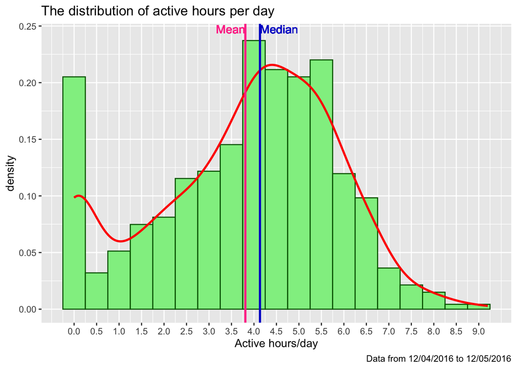

```r
ggplot(daily_activity, aes(x = total_daily_active_hours)) +
  geom_histogram(aes(y = ..density..), fill = "lightgreen", color = "darkgreen", binwidth = 0.5) +
  geom_density(color = "red", linewidth = 1) +
  scale_x_continuous(breaks = seq(0, 9, by = 0.5)) +
  geom_vline(aes(xintercept = median(total_daily_active_hours)), color = "blue3", size = 1) +
  geom_vline(aes(xintercept = mean(total_daily_active_hours)), color = "violetred1", size = 1) +
  geom_text(aes(x = median(total_daily_active_hours), y = 0.24, label = "Median"),
            color = "blue3", size = 4, angle = 0, vjust = -0.5, hjust = 0) +
  geom_text(aes(x = mean(total_daily_active_hours), y = 0.24, label = "Mean"),
            color = "violetred1", size = 4, angle = 0, vjust = -0.5, hjust = 1) +
  labs(title = "The distribution of active hours per day",
       x = "Active hours/day",
       caption = "Data from 12/04/2016 to 12/05/2016")
```

I want to compare this to the distribution of sleeping time/day:

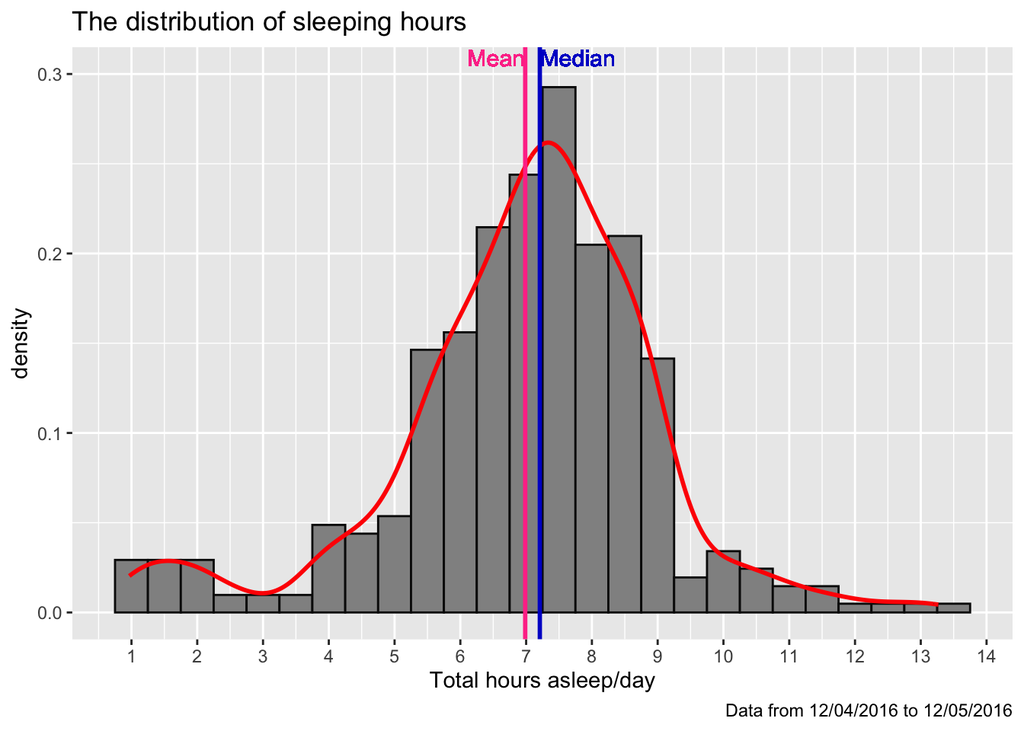

```r
ggplot(daily_sleep, aes(x = (total_minutes_asleep/60))) +
  geom_histogram(aes(y = ..density..), binwidth = 0.5, fill = "gray57", color = "gray4") +
  geom_density(color = "red", linewidth = 1) +
  scale_x_continuous(breaks = seq(0, 14, by = 1)) +
  geom_vline(aes(xintercept = median(total_minutes_asleep/60)), color = "blue3", size = 1) +
  geom_vline(aes(xintercept = mean(total_minutes_asleep/60)), color = "violetred1", size = 1) +
  geom_text(aes(x = median(total_minutes_asleep/60), y = 0.3, label = "Median"),
            color = "blue3", size = 4, angle = 0, vjust = -0.5, hjust = 0) +
  geom_text(aes(x = mean(total_minutes_asleep/60), y = 0.3, label = "Mean"),
            color = "violetred1", size = 4, angle = 0, vjust = -0.5, hjust = 1) +
  labs(title = "The distribution of sleeping hours",
       x = "Total hours asleep/day",
       caption = "Data from 12/04/2016 to 12/05/2016")
```

In this case, the histogram is fairly symmetrical, with the mean and median both being around 7 hours per day. Most users sleep between 6.5-8.5 hours which aligns with the [doctors’ recommendations](https://www.nhlbi.nih.gov/health/sleep/how-much-sleep) of 7-9 hours for adults. If we deepdive into the monthly sleep dataframe, we can see that all the outlier sleeping hours (extremely low and extremely high numbers) come from users who logged less than 9 nights during the one month.

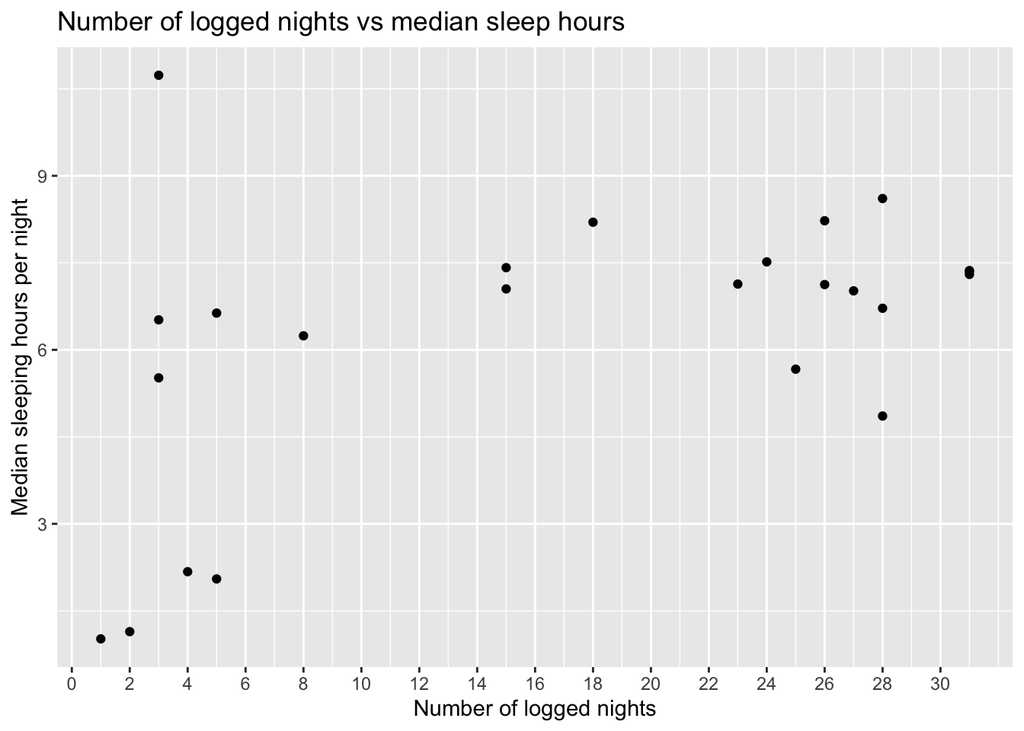

```r
ggplot(monthly_sleep) +
  geom_point(mapping = aes(x = number_of_nights, y = med_sleep_hrsperday)) +
  labs(title = "Number of logged nights vs median sleep hours",
       x = "Number of logged nights",
       y = "Median sleeping hours per night") +
  scale_x_continuous(breaks = seq(0, 31, by = 2))
```

I want to compare the sleeping hours with the activity level. In the next plot, each dot represents a user, the number next to each dot is the number of logged nights. I also included the activity intensity score. There does not appear to be a clear correlation between the number of active hours per day and the amount of sleep. Some users have high activity levels but relatively low sleep hours, while others show the opposite pattern. The intensity score also does not seem to be strongly linked to either active hours or sleep duration. There is a mix of users across the different activity and sleep levels.

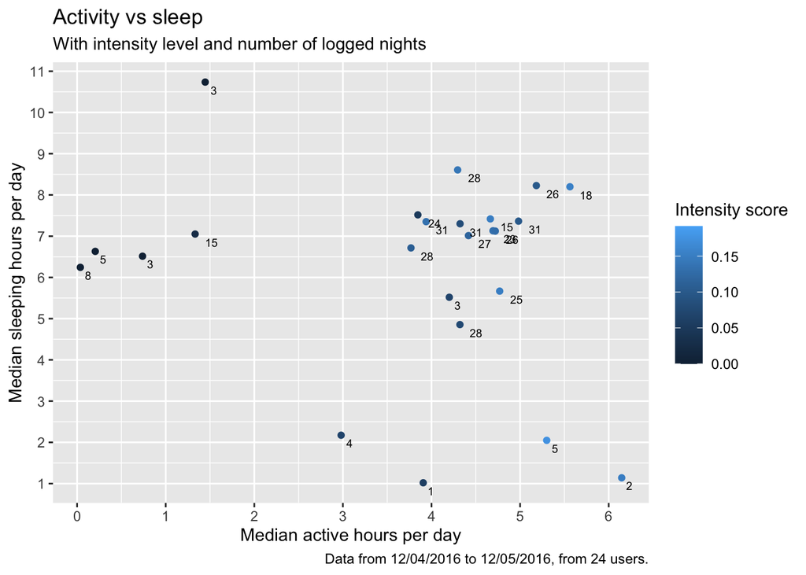

```r
ggplot(monthly_activity) +
  geom_jitter(mapping = aes(x = med_active_hrsperday, y = med_sleep_hrsperday, color = med_monthly_intensity)) +
  geom_text(aes(x = med_active_hrsperday, y = med_sleep_hrsperday, label = number_of_nights), vjust = 1.5, hjust = -0.8, size = 2.5) +
  scale_x_continuous(breaks = seq(0, 6.5, by = 1)) +
  scale_y_continuous(breaks = seq(0, 11, by = 1)) +
  labs(title = "Activity vs sleep",
       subtitle = "With intensity level and number of logged nights",
       x = "Median active hours per day",
       y = "Median sleeping hours per day",
       color = "Intensity score",
       caption = "Data from 12/04/2016 to 12/05/2016, from 24 users.")
```

Let’s see the active and sleep hours by weekdays! Which weekdays are the most and least active? On which weekdays do the users sleep the most and the least?

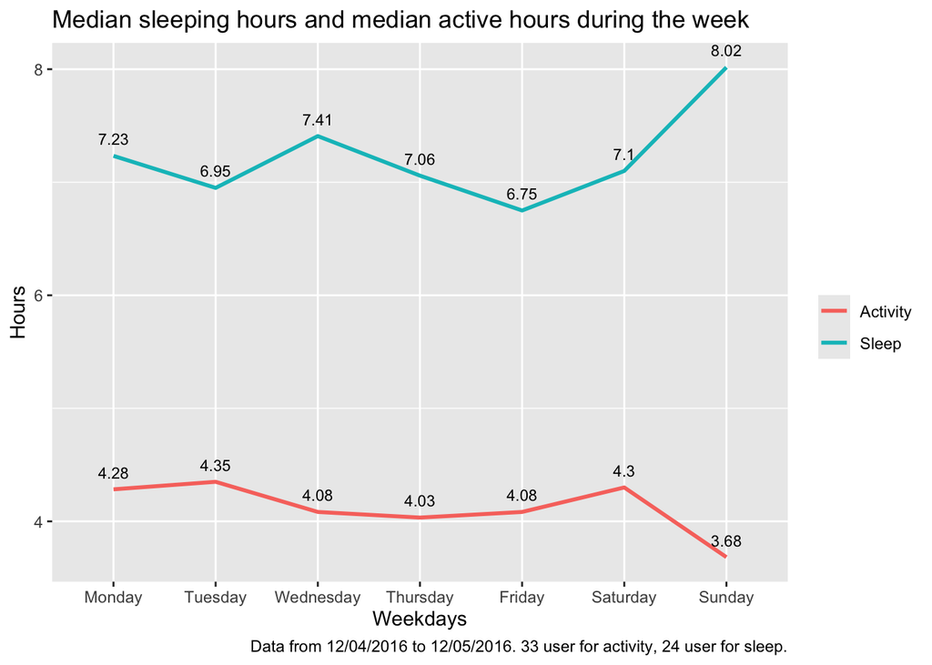

```r
ggplot() +
  geom_line(data = active_weekdays, aes(x = weekdays, y = med_activity_hrsperday, group = 1, color = "Activity"), size = 1) +
  geom_line(data = sleep_weekdays, aes(x = weekdays, y = med_sleep_hrsperday, group = 1, color = "Sleep"), size = 1) +
  geom_text(data = active_weekdays, aes(x = weekdays, y = med_activity_hrsperday, label = round(med_activity_hrsperday, 2)), size = 3, vjust = -1) +
  geom_text(data = sleep_weekdays, aes(x = weekdays, y = med_sleep_hrsperday, label = round(med_sleep_hrsperday, 2)), size = 3, vjust = -1) +
  scale_y_continuous(breaks = seq(0, 8, by = 2)) +
  labs(title = "Median sleeping hours and median active hours during the week",
       x = "Weekdays",
       y = "Hours",
       color = " ",
       caption = "Data from 12/04/2016 to 12/05/2016. 33 user for activity, 24 user for sleep.")
```

As the plot shows, the week usually starts strong, with higher activity and less sleep. By Wednesday, users tend to get tired, as their sleep increases and active hours decrease. While the active hours remain low, sleep hours also hit rock bottom on Friday - I assume it’s due to typical Friday night activities like socializing and winding down after the work week. Saturday is the second most active day, and sleep also increases - users seem to have more time during the weekend for these activities. Sunday on the other hand is all about resting with the highest sleeping hours and lowest active hours. Keeping in mind this weekly pattern can be useful when planning the company’s marketing strategy.

Let’s see the sleep quality by examining the sleep values measured by the devices during the sleeping hours. The devices assigned a value to every sleeping minute. According to the Fitabase Data Dictionary, the values mean: 1 = asleep, 2 = restless, 3 = awake. First, I’ll count the number of each value occurring in the dataframe, and calculate the percentages. Then I’ll create a pie chart displaying the share of each value.

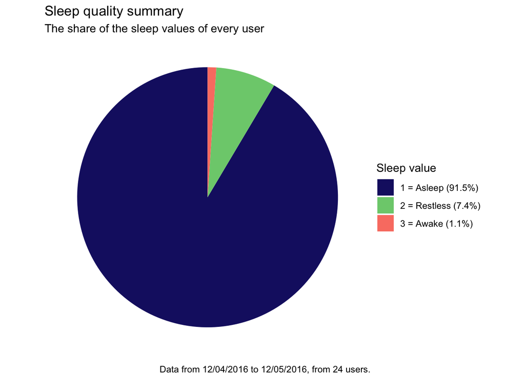

```r
sleep_value <- minute_sleep %>%
  group_by(value) %>%
  summarize(count = n()) %>%
  mutate(percentage = count/sum(count) * 100,
         label = paste0(c("1 = Asleep", "2 = Restless", "3 = Awake")[value],
                        " (", round(percentage, 1), "%)"))

ggplot(sleep_value, aes(x = "", y = count, fill = factor(value))) +
  geom_bar(stat = "identity", width = 1) +
  coord_polar("y") +
  scale_fill_manual(
    values = c("midnightblue", "palegreen3", "salmon"),
    labels = sleep_value$label) +
  labs(title = "Sleep quality summary",
       subtitle = "The share of the sleep values of every user",
       fill = "Sleep value",
       caption = "Data from 12/04/2016 to 12/05/2016, from 24 users.") +
  theme_void()
```

It’s difficult to interpret these values as Fitbit doesn’t provide any explanation on how these values are measured, and what’s their definition. However, the values cannot be matched with the sleep stages recognized by the [Sleep Foundation](https://www.sleepfoundation.org/stages-of-sleep). Without more context on the methodology, it is challenging to assess the accuracy or meaning of these specific sleep quality metrics.

I want to examine the activity pattern by comparing the total active hours with the median active hours:

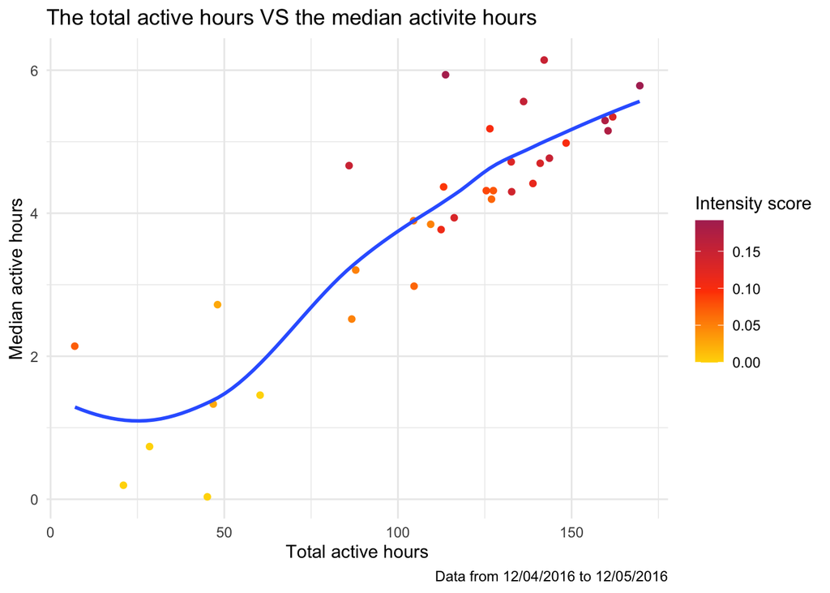

```r
ggplot(monthly_activity, aes(x = total_active_hrs, y = med_active_hrsperday, color = med_monthly_intensity)) +
  geom_jitter() +
  geom_smooth(se = F) +
  scale_color_gradientn(
    colors = c("gold", "orangered", "maroon"),
    name = "Intensity score"
  ) +
  labs(
    title = "The total active hours VS the median activite hours",
    x = "Total active hours",
    y = "Median active hours",
    caption = "Data from 12/04/2016 to 12/05/2016"
  ) +
  theme_minimal()
```

The plot shows a positive relationship between the median and the total active hours, but with a diverse pattern regarding intensity levels. I want to see the correlation coefficient between these two values:

```r
cor(monthly_activity$total_active_hrs, monthly_activity$med_active_hrsperday)
```

```
## [1] 0.8846444
```

The correlation coefficient between the total active hours and median active hours is 0.88464440, indicating a strong positive relationship. Users generally maintain a steady and consistent level of activity throughout the month. There aren’t any users who engage in a lot of activity all at once and then remain inactive for the rest of the month, nor are there users who perform very short bursts of activity extremely frequently. By the spread of points, users with lower activity levels show the least consistency.  
In terms of intensity, the most active users tend to have the highest intensity levels - similarly, users with higher median active hours but with slightly lower total active hours also have high intensity levels.

# ACT

## How could these trends apply to Bellabeat customers?

Bellabeat users may also face similar inconsistencies in device usage and data logging. Addressing these issues should be a priority to ensure reliable data for analysis. Potential next steps include:

- Investigating the reasons behind inconsistent data logging.
- Improving the logging process through user feedback, technical updates, or campaigns encouraging more accurate and consistent data entry.

Additionally, a notable gap in the dataset is the absence of reproductive health data. Bellabeat, as a company focused on women’s health, could greatly benefit from exploring usage trends related to reproductive health. Such insights could inform the development of new, women-centric features and products that cater directly to their target audience.

## How could these trends help influence Bellabeat marketing strategy?

- **Gamification and incentives:** Introduce personalized reminders, weekly challenges, and leaderboards to encourage consistent device usage. Offer prizes, such as discount coupons, for top performers.
- **Partnerships:** Collaborate with sportswear brands, dietitians, or fitness trainers. Joint campaigns and exclusive offers can increase activity levels and strengthen brand positioning.
- **Personalization:** Provide users with a customized app interface, personal avatars, and badges. Use their activity and sleep data to deliver tailored recommendations, such as workout plans or guided meditations.
- **Data quality control:** Implement systems to detect inconsistent logging early on and prompt users with reminders or notifications. Allow data edits to correct inaccuracies.
- **Focus on women:** Emphasize Bellabeat’s commitment to women’s health. Expand the product line to include not only smart devices but also clothing, accessories, fitness equipment, or professional services like consultations with personal trainers and dietitians.

## Conclusion

To improve user experience and reliability of data insights, Bellabeat should address challenges with inconsistent logging and expand their offerings to cater more specifically to women’s health needs. By leveraging personalized engagement strategies and focusing on empowering women through innovative products, Bellabeat can enhance its market presence while staying true to its core mission.